# An Analysis of the effects of Health, Democracy, Education, and Economy on Internet Usage

## Introduction

In this presentation, we attempt to analyze the relationship between internet usage by country and the following variables by observing their correlations and creating models and prediction trees for the more distinctly noticeable relationships.

```
##     country              region percent_internet population
## 2   Albania              Europe       0.66158944    3047987
## 3   Algeria         Arab States       0.42205756   40969443
## 6    Angola              Africa       0.08947044   29310273
## 9 Argentina South/Latin America       0.69506887   44293293
##   democracy_score life_expectancy education_gdp_percentage
## 2           0.598            78.5                    0.033
## 3           0.356            77.0                    0.043
## 6           0.362            60.2                    0.035
## 9           0.696            77.3                    0.063
##   healthcare_gdp_percentage gdp_per_capita telephones
## 2                     0.059          12500     247010
## 3                     0.072          15200    3130090
## 6                     0.033           6800     161070
## 9                     0.048          20900    9530349
```

## Objectives

We will also complete the following tasks:

1. Define how internet usage is measured in a country for this presentation
2. Determine whether different regions of the world have different internet usage
3. Define how democracy, education, economy, and health are measured for this presentation, and determine the impact of democracy, education, economy, and health on internet use.

## Data Cleaning

- Created new data frames which match internet usage to coresponding observation - health expenditures, GDP per capita, and so on.
- An overall data frame was used containing each given observation for each variable, by using **merge()** to merge each of the individual data frames together and then using **select()** to choose individual variables within the data frame.
- We also used **mutate()** to create several other additional variables, such as internet usage as a proportion of the country’s population.

## Data Cleaning - continued

- We used **gsub** to rename countries and remove symbols so that each country’s name was consistent across the data frame.
- We also scaled down some variables, such democracy score, so that they could be analyzed as a value from 0-1.
- We removed countries for which not enough information was given using **filter()** - however, if data for one of the variables was present, we used the country later to predict internet usage based on our models.

## Statistical Methods - Introducing Variables

- Democracy Index - A score given from 0-10 by the EIU, intended to measure a country’s state of democracy
- Education Expenditures - The proportion of a country’s GDP spent on education
- GDP Per Capita (PPP) - A country’s GDP for one year based on purchasing power parity, divided by the population of the country
- Life Expectancy - The predicted age of death for everyone born in a given year in a given country

## Statistical Methods - Introducing Variables (continued)

- Health Expenditures - The proportion of a country’s GDP spent on healthcare
- Telephone Lines - A country’s total number of main telephone lines in use
- Population - The total population of the country
- Geographical Location - The geographical region a country is located - these include Africa, Arab States, Asia & Pacific, Europe, North America and South/Latin America

## Statistical Methods - Prediction Tree

- We created a prediction tree using **rpart()** for predicting **internet usage** by **GDP per capita**, using 80% of the data to train the algorithm to create the classification trees and 20% of the data for testing the tree.

## Statistical Methods - Regression Models

- We determined correlation for each relationship, but this alone doesn’t tell us much.
- We created regression models for predicting **internet usage** by **life expectancy**. **Life expectancy** was used since it had a strong correlation with **internet usage**, and thus our model would be more likely to more accurately predict **internet usage** for which no data was given.

## Statistical Methods - Analyzing our predictions

- We compared the predicted results of **internet usage** in our testing data for both our prediction tree and regression model to what the World Factbook actually reported them as.
- This gave us some indication of how accurate our models really were.

## Results - Democracy Score

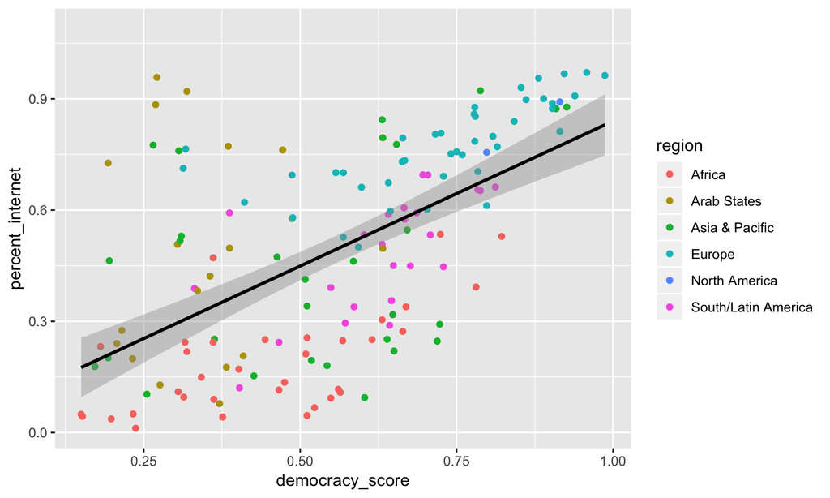

```
## [1] 0.3504583
```

## Results - Life Expectancy

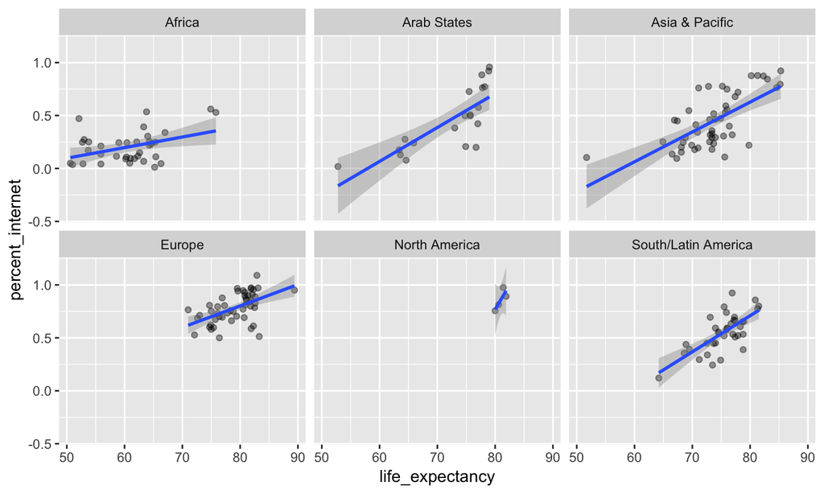

```
## [1] 0.6306507
```

## Results - GDP Per Capita

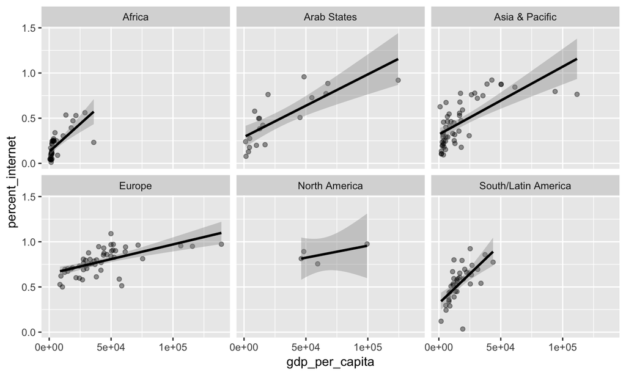

```
## [1] 0.5384906
```

##Results - Healthcare Expenditures

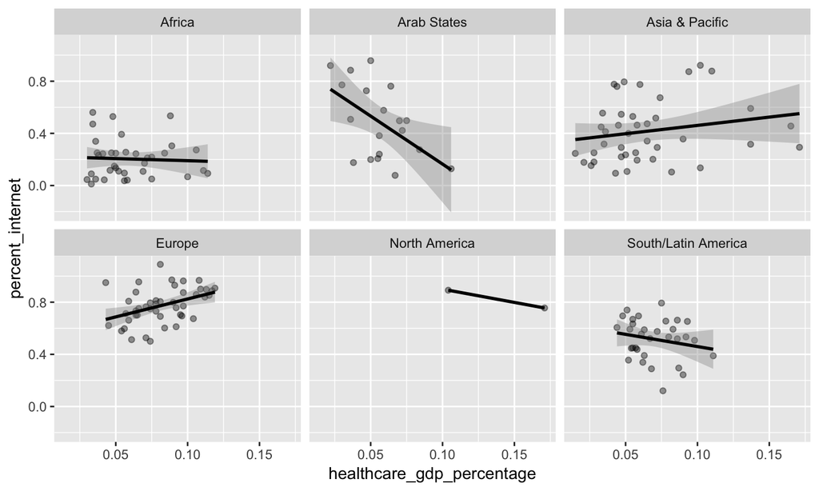

```
## [1] 0.07435327
```

##Results - Education Expenditures

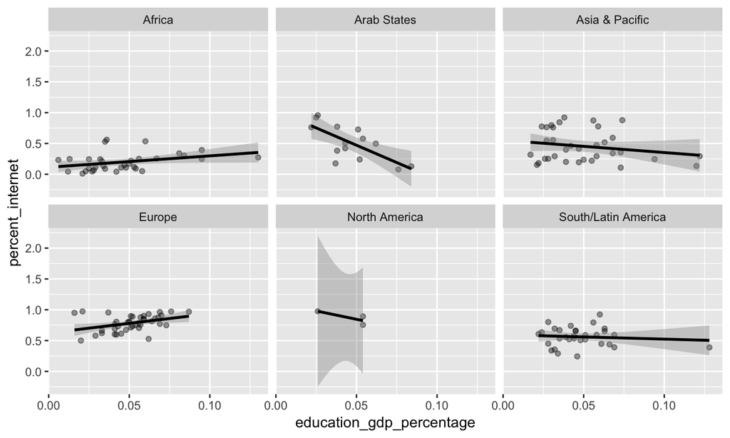

```
## [1] 0.0002510039
```

##Results - Internet Usage by Country

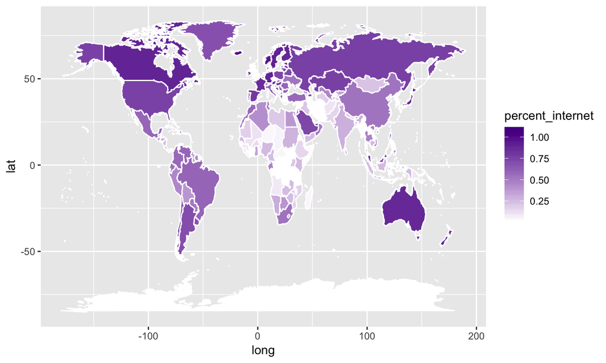

##Results - Classification Tree

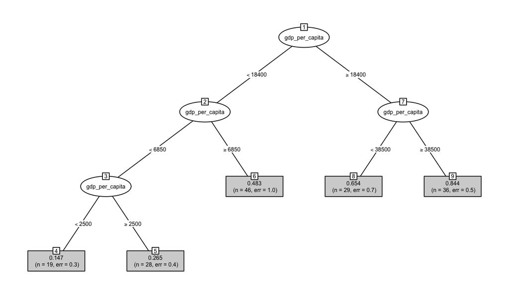

```
## [1] 0.3626904
```

```
## [1] 0.144672
```

##Results - Regression model using life expectancy to predict Internet Usage

```
## [1] 0.3544449
```

```
## [1] 0.1919223
```

```
##                    Estimate  Std. Error   t value     Pr(>|t|)
## (Intercept)     -1.48706897 0.120383640 -12.35275 8.517428e-25
## life_expectancy  0.02740132 0.001640219  16.70589 2.109618e-36
```

##Results - Predicted internet usage by GDP per Capita

```
##       country actual_internet predicted_internet   difference
## 34      Chile       0.6549365          0.6539387 0.0009977948
## 37   Ethiopia       0.1493283          0.1470303 0.0022980094
## 6       Kenya       0.2554953          0.2653943 0.0098990213
## 20    Belgium       0.8589711          0.8444015 0.0145696014
## 30 Uzbekistan       0.4635836          0.4833522 0.0197686302
```

```
##                   country actual_internet predicted_internet difference
## 19           Saint Martin      0.03424125          0.6539387  0.6196974
## 7                   Libya      0.19933145          0.4833522  0.2840208
## 31 Bosnia and Herzegovina      0.69434033          0.4833522  0.2109881
## 35             Costa Rica      0.65255753          0.4833522  0.1692053
## 26              Sri Lanka      0.31801592          0.4833522  0.1653363
```

##Results - Predicted Internet usage by Life Expectancy

```
##       country actual_internet predicted_internet difference
## 4      Israel       0.7857554          0.7735399 0.01221553
## 17   Portugal       0.7038655          0.6885958 0.01526970
## 34 Costa Rica       0.6525575          0.6694149 0.01685734
## 6       Kenya       0.2554953          0.2748359 0.01934059
## 33      Chile       0.6549365          0.6748951 0.01995866
```

```
##            country actual_internet predicted_internet difference
## 22 Solomon Islands       0.1078769          0.5844708  0.4765939
## 7            Libya       0.1993315          0.6146122  0.4152808
## 15      Bangladesh       0.1805737          0.5241879  0.3436142
## 25       Sri Lanka       0.3180159          0.6200925  0.3020766
## 5       Kazakhstan       0.7598739          0.4611648  0.2987091
```

## Conclusion

- We were able to confidently the strength of the relationships between internet usage and health, education, democracy, and economy based on the given data.
- There is almost certainly a positive association between internet usage and economy and internet usage and health, as well as a weaker positive association between internet usage and democracy.
- We observed no relationship between education and internet usage.

## Conclusion (continued)

- We found it difficult to create suitable definitions of “democracy”, “health”, “education”, and “economy” for this project, as we were challenged to come up with clear definitions which involved all of the data we used.
- Despite this, the relationships between each variable and internet usage were generally either fairly strong or extremely weak, and for each case we found evidence to support either a real association or a lack of one.
- Although we obtained generally favourable results, there are some improvements we could have made to our project. In particular, we would have liked to use the United Nations’ Education Index, published annually, which measures a country’s adult literacy rate and gross academic enrollment ratio.